# Social Circle Dataset EDA

Use this notebook to understand the `learning-social-circles` ego-network data (graphs plus circle labels) before modeling. Update the data path below, then run the cells to inspect structure, scale, and label coverage.

```python
import os
from itertools import combinations, islice
from math import comb
from pathlib import Path

import networkx as nx
import numpy as np
import pandas as pd

import matplotlib.pyplot as plt
import seaborn as sns

from IPython.display import display

pd.set_option("display.max_columns", 50)
pd.set_option("display.width", 120)
```

## Locate the dataset

Set `BASE_DIR` to the root of the `learning-social-circles` download (it should contain `egonets/` and `Training/`).

```python
NOTEBOOK_DIR = Path.cwd().resolve()
PROJECT_ROOT = NOTEBOOK_DIR.parent if NOTEBOOK_DIR.name.lower() == "eda" else NOTEBOOK_DIR

candidates = []
env_dir = os.getenv("SOCIAL_CIRCLE_DATA_DIR")
if env_dir:
    candidates.append(Path(env_dir).expanduser())

candidates += [
    PROJECT_ROOT / "data" / "learning-social-circles",
    PROJECT_ROOT / "datasets" / "learning-social-circles",
    PROJECT_ROOT.parent / "datasets" / "learning-social-circles",
    Path("/Users/sruzics/Downloads/learning-social-circles"),
]

BASE_DIR = next((p for p in candidates if p.is_dir()), None)
if BASE_DIR is None:
    BASE_DIR = Path("/path/to/learning-social-circles").expanduser()

EGONET_DIR = BASE_DIR / "egonets"
CIRCLES_DIR = BASE_DIR / "Training"

print(f"Notebook directory: {NOTEBOOK_DIR}")
print(f"Project root guess: {PROJECT_ROOT}")
print(f"Using BASE_DIR: {BASE_DIR}")
print(f"Egonet dir present? {EGONET_DIR.exists()}  Circles dir present? {CIRCLES_DIR.exists()}")

if not EGONET_DIR.exists() or not CIRCLES_DIR.exists():
    raise FileNotFoundError("Set BASE_DIR to the folder containing 'egonets' and 'Training' from the learning-social-circles dataset.")
```

```
Notebook directory: /Users/sruzics/Recommender-System-SocialCircle-1/EDA
Project root guess: /Users/sruzics/Recommender-System-SocialCircle-1
Using BASE_DIR: /Users/sruzics/Downloads/learning-social-circles
Egonet dir present? True  Circles dir present? True
```

## Peek at raw files

Check how many ego-networks and circle label files are available and inspect a sample to confirm the expected format.

```python
def ids_from_dir(path: Path, suffix: str):
    ids = []
    for p in path.glob(f"*{suffix}"):
        try:
            ids.append(int(p.stem))
        except ValueError:
            continue
    return sorted(ids)


def peek(path: Path, n: int = 5):
    print(f"-- {path} --")
    with path.open("r") as f:
        for line in islice(f, n):
            print(line.rstrip())
    print()

ego_ids = ids_from_dir(EGONET_DIR, ".egonet")
circle_ids = ids_from_dir(CIRCLES_DIR, ".circles")
labeled_ego_ids = [eid for eid in ego_ids if eid in set(circle_ids)]

print(f"Egos with egonet file: {len(ego_ids)}")
print(f"Egos with circle labels: {len(circle_ids)}")
print(f"Egos we can analyze (graph + labels): {len(labeled_ego_ids)}")
print(f"Example ego IDs: {labeled_ego_ids[:8]}")

if labeled_ego_ids:
    sample_ego = labeled_ego_ids[0]
    peek(EGONET_DIR / f"{sample_ego}.egonet", n=5)
    peek(CIRCLES_DIR / f"{sample_ego}.circles", n=5)
else:
    print("No overlapping egonet/circle files found.")
```

```
Egos with egonet file: 110
Egos with circle labels: 60
Egos we can analyze (graph + labels): 60
Example ego IDs: [239, 345, 611, 1357, 1839, 1968, 2255, 2365]
-- /Users/sruzics/Downloads/learning-social-circles/egonets/239.egonet --
240: 283 241 334 285 309 310
241: 283 334 242 273 285 240 286 305 263 274 339 309 310 269
242: 283 241 273 285 286 305 263 274 339 269
243: 325 320 258 276 301 337 251 267 302 294 313 339 336 264 266
244: 252 328 340 257

-- /Users/sruzics/Downloads/learning-social-circles/Training/239.circles --
circle17: 306 281 311 247 342 315 297 303 304 343 333 296 250 255 331 248 340 265 322 289 344 287 326 249 324 307 290
circle16: 335 253 325 320 283 258 284 318 330 241 276 312 340 301 334 291 295 242 337 338 273 277 293 251 279 285 267 243 240 298 302 286 305 282 294 256 313 263 274 339 309 336 310 264 266 269
circle19: 280 308 254 246 270 314 299 329 261 271 327 259 317
circle18: 300 252 332 328 268 272 323 288 257 292 245 319 275 341 282 321 339 244 316
```

## Parsing helpers

Utilities to load an ego-network graph and the corresponding circle memberships (labelled positive pairs).

```python
def load_egonet(ego_id: int, egonet_dir: Path = EGONET_DIR) -> nx.Graph:
    """Load a single ego-network as an undirected graph."""
    ego_file = egonet_dir / f"{ego_id}.egonet"
    if not ego_file.exists():
        raise FileNotFoundError(f"Missing egonet file: {ego_file}")

    G = nx.Graph()
    G.add_node(ego_id, is_ego=True)

    with ego_file.open("r") as f:
        for raw_line in f:
            line = raw_line.strip()
            if not line or ":" not in line:
                continue

            left, right = line.split(":", 1)
            u = int(left.strip())
            if u not in G:
                G.add_node(u, is_ego=False)
            G.add_edge(ego_id, u)

            neighbors_str = right.strip()
            if neighbors_str:
                for tok in neighbors_str.split():
                    v = int(tok)
                    if v not in G:
                        G.add_node(v, is_ego=False)
                    G.add_edge(u, v)

    return G


def load_circles(ego_id: int, circles_dir: Path = CIRCLES_DIR):
    """Load circles and derive positive labeled pairs for an ego."""
    circle_file = circles_dir / f"{ego_id}.circles"
    if not circle_file.exists():
        raise FileNotFoundError(f"Missing circle file: {circle_file}")

    circles = {}
    pair_labels = {}

    with circle_file.open("r") as f:
        for raw_line in f:
            line = raw_line.strip()
            if not line or ":" not in line:
                continue

            name_part, members_part = line.split(":", 1)
            circle_name = name_part.strip()
            members = {int(tok) for tok in members_part.strip().split()} if members_part.strip() else set()
            circles[circle_name] = members

            # mark positive pairs
            for u, v in combinations(sorted(members), 2):
                pair_labels[frozenset((u, v))] = 1

    return circles, pair_labels
```

## Dataset-level summary

Aggregate simple graph and label statistics across all egos that have both graph structure and circle annotations.

```python
def summarize_ego(ego_id: int):
    G = load_egonet(ego_id)
    circles, pos_pairs = load_circles(ego_id)

    node_count = G.number_of_nodes()
    edge_count = G.number_of_edges()
    circle_sizes = [len(members) for members in circles.values()]
    member_pool = set().union(*circles.values()) if circles else set()

    total_pairs = comb(len(member_pool), 2) if len(member_pool) >= 2 else 0
    pos_pairs_count = len(pos_pairs)

    summary = {
        "ego_id": ego_id,
        "node_count": node_count,
        "edge_count": edge_count,
        "avg_degree": (2 * edge_count / node_count) if node_count else 0.0,
        "density": nx.density(G) if node_count > 1 else 0.0,
        "avg_clustering": nx.average_clustering(G) if node_count > 1 else 0.0,
        "circle_count": len(circles),
        "circle_min_size": int(np.min(circle_sizes)) if circle_sizes else 0,
        "circle_median_size": float(np.median(circle_sizes)) if circle_sizes else 0.0,
        "circle_max_size": int(np.max(circle_sizes)) if circle_sizes else 0,
        "positive_pairs": pos_pairs_count,
        "total_pairs": total_pairs,
        "positive_ratio": (pos_pairs_count / total_pairs) if total_pairs else 0.0,
    }

    return summary


summary_df = pd.DataFrame([summarize_ego(eid) for eid in labeled_ego_ids])
summary_df = summary_df.sort_values("ego_id").reset_index(drop=True)

print(f"Summary shape: {summary_df.shape}")
display(summary_df.head(10))
display(summary_df.describe(include="all").transpose())
```

```
Summary shape: (60, 13)
```

|  | ego_id | node_count | edge_count | avg_degree | density | avg_clustering | circle_count | circle_min_size | circle_median_size | circle_max_size | positive_pairs | total_pairs | positive_ratio |
| --- | --- | --- | --- | --- | --- | --- | --- | --- | --- | --- | --- | --- | --- |
| 0 | 239 | 106 | 447 | 8.433962 | 0.080323 | 0.782560 | 4 | 13 | 23.0 | 46 | 1634 | 5151 | 0.317220 |
| 1 | 345 | 266 | 6450 | 48.496241 | 0.183005 | 0.643479 | 7 | 6 | 27.0 | 145 | 12410 | 31375 | 0.395538 |
| 2 | 611 | 239 | 2527 | 21.146444 | 0.088851 | 0.692337 | 10 | 8 | 20.0 | 108 | 8135 | 27966 | 0.290889 |
| 3 | 1357 | 456 | 6002 | 26.324561 | 0.057856 | 0.575223 | 10 | 7 | 10.0 | 64 | 2996 | 8128 | 0.368602 |
| 4 | 1839 | 129 | 939 | 14.558140 | 0.113735 | 0.674609 | 8 | 5 | 27.5 | 54 | 2710 | 6903 | 0.392583 |
| 5 | 1968 | 287 | 2607 | 18.167247 | 0.063522 | 0.674213 | 14 | 6 | 11.5 | 85 | 8344 | 36585 | 0.228072 |
| 6 | 2255 | 110 | 1319 | 23.981818 | 0.220017 | 0.796522 | 3 | 6 | 51.0 | 93 | 4293 | 4851 | 0.884972 |
| 7 | 2365 | 108 | 653 | 12.092593 | 0.113015 | 0.749855 | 10 | 5 | 12.0 | 36 | 1345 | 5050 | 0.266337 |
| 8 | 2738 | 52 | 102 | 3.923077 | 0.076923 | 0.637186 | 4 | 5 | 6.5 | 7 | 67 | 300 | 0.223333 |
| 9 | 2790 | 105 | 770 | 14.666667 | 0.141026 | 0.656651 | 8 | 5 | 10.0 | 54 | 1505 | 2080 | 0.723558 |

|  | count | mean | std | min | 25% | 50% | 75% | max |
| --- | --- | --- | --- | --- | --- | --- | --- | --- |
| ego_id | 60.0 | 12072.183333 | 8263.743229 | 239.000000 | 5116.250000 | 10662.000000 | 18139.500000 | 27022.000000 |
| node_count | 60.0 | 242.983333 | 151.863843 | 46.000000 | 117.500000 | 220.000000 | 323.000000 | 671.000000 |
| edge_count | 60.0 | 3143.083333 | 4008.312677 | 102.000000 | 819.000000 | 1845.000000 | 3945.500000 | 25368.000000 |
| avg_degree | 60.0 | 20.862913 | 14.116545 | 3.923077 | 11.532826 | 16.690783 | 26.470273 | 95.368421 |
| density | 60.0 | 0.101502 | 0.051642 | 0.022288 | 0.063362 | 0.086350 | 0.120432 | 0.221980 |
| avg_clustering | 60.0 | 0.693178 | 0.060967 | 0.512657 | 0.655168 | 0.689030 | 0.737273 | 0.827022 |
| circle_count | 60.0 | 9.866667 | 5.558523 | 3.000000 | 5.000000 | 9.000000 | 12.250000 | 28.000000 |
| circle_min_size | 60.0 | 6.750000 | 3.985673 | 5.000000 | 5.000000 | 5.000000 | 6.000000 | 30.000000 |
| circle_median_size | 60.0 | 17.633333 | 9.684807 | 5.000000 | 11.000000 | 16.250000 | 21.625000 | 51.000000 |
| circle_max_size | 60.0 | 87.166667 | 66.359618 | 7.000000 | 45.250000 | 70.500000 | 109.500000 | 335.000000 |
| positive_pairs | 60.0 | 8796.316667 | 13701.271655 | 67.000000 | 1601.750000 | 4300.000000 | 9509.250000 | 67863.000000 |
| total_pairs | 60.0 | 28250.850000 | 41690.792527 | 300.000000 | 5000.250000 | 11215.500000 | 31437.750000 | 220780.000000 |
| positive_ratio | 60.0 | 0.351278 | 0.161040 | 0.119523 | 0.248743 | 0.322187 | 0.404332 | 0.890581 |

## Distributions

Visual look at scale and label coverage per ego.

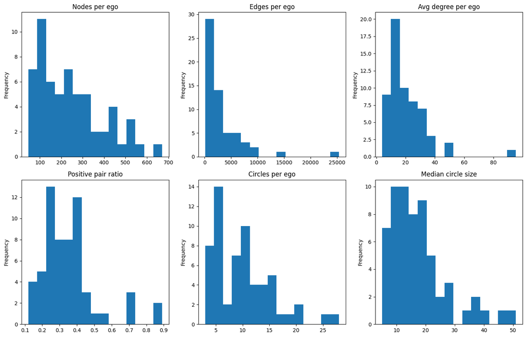

```python
if  not summary_df.empty:
    fig, axes = plt.subplots(2, 3, figsize=(14, 9))

    summary_df["node_count"].plot(kind="hist", bins=15, ax=axes[0, 0], title="Nodes per ego")
    summary_df["edge_count"].plot(kind="hist", bins=15, ax=axes[0, 1], title="Edges per ego")
    summary_df["avg_degree"].plot(kind="hist", bins=15, ax=axes[0, 2], title="Avg degree per ego")

    summary_df["positive_ratio"].plot(kind="hist", bins=15, ax=axes[1, 0], title="Positive pair ratio")
    summary_df["circle_count"].plot(kind="hist", bins=15, ax=axes[1, 1], title="Circles per ego")
    summary_df["circle_median_size"].plot(kind="hist", bins=15, ax=axes[1, 2], title="Median circle size")

    plt.tight_layout()
else:
    print("No plots rendered; either summary_df is empty or matplotlib/seaborn is unavailable.")
```

## Dive into a single ego

Inspect degree distribution, circle sizes, and circle overlaps for a representative ego (picked as the one with the most circles).

```
Inspecting ego 4406
Nodes: 423  Edges: 3834  Density: 0.0430
Circles: 28  Median circle size: 16.5
Positive labeled pairs: 60860 / 88831 possible (68.51% if total_pairs else 0)%

Non-empty circle overlaps (top 10):
```

|  | ego_id | circle_a | circle_b | overlap | jaccard |
| --- | --- | --- | --- | --- | --- |
| 31 | 4406 | circle400 | circle18 | 162 | 0.435484 |
| 16 | 4406 | circle400 | circle25 | 74 | 0.242623 |
| 17 | 4406 | circle400 | circle419 | 60 | 0.194805 |
| 74 | 4406 | circle419 | circle18 | 48 | 0.195122 |
| 14 | 4406 | circle400 | circle405 | 41 | 0.134868 |
| 42 | 4406 | circle403 | circle18 | 33 | 0.135802 |
| 56 | 4406 | circle405 | circle18 | 32 | 0.133891 |
| 48 | 4406 | circle402 | circle18 | 28 | 0.118143 |
| 13 | 4406 | circle400 | circle402 | 26 | 0.083067 |
| 43 | 4406 | circle402 | circle405 | 24 | 0.461538 |

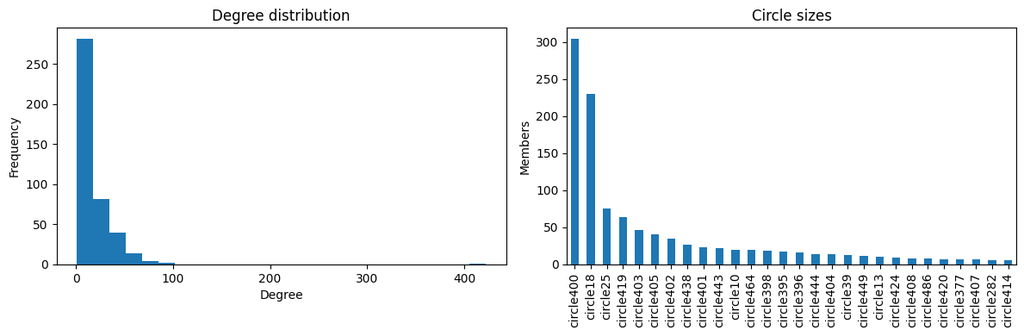

```python
if summary_df.empty:
    print("Nothing to inspect; summary_df is empty.")
else:
    focus_ego = int(summary_df.sort_values("circle_count", ascending=False).iloc[0]["ego_id"])
    print(f"Inspecting ego {focus_ego}")

    G_focus = load_egonet(focus_ego)
    circles_focus, pos_pairs_focus = load_circles(focus_ego)

    deg_series = pd.Series(dict(G_focus.degree()))
    circle_sizes = pd.Series({name: len(members) for name, members in circles_focus.items()}).sort_values(ascending=False)

    member_pool = set().union(*circles_focus.values()) if circles_focus else set()
    total_pairs = comb(len(member_pool), 2) if len(member_pool) >= 2 else 0
    pos_pairs_count = len(pos_pairs_focus)

    print(f"Nodes: {G_focus.number_of_nodes()}  Edges: {G_focus.number_of_edges()}  Density: {nx.density(G_focus):.4f}")
    print(f"Circles: {len(circles_focus)}  Median circle size: {circle_sizes.median() if not circle_sizes.empty else 0}")
    print(f"Positive labeled pairs: {pos_pairs_count} / {total_pairs} possible ({(pos_pairs_count / total_pairs * 100):.2f}% if total_pairs else 0)%")

    fig, axes = plt.subplots(1, 2, figsize=(12, 4))
    deg_series.plot(kind="hist", bins=25, ax=axes[0], title="Degree distribution")
    axes[0].set_xlabel("Degree")

    if not circle_sizes.empty:
        circle_sizes.plot(kind="bar", ax=axes[1], title="Circle sizes")
        axes[1].set_ylabel("Members")
    else:
        axes[1].set_visible(False)

    plt.tight_layout()

    overlap_rows = []
    for (name_a, members_a), (name_b, members_b) in combinations(circles_focus.items(), 2):
        overlap = len(members_a & members_b)
        if overlap:
            union = len(members_a | members_b)
            overlap_rows.append({
                "ego_id": focus_ego,
                "circle_a": name_a,
                "circle_b": name_b,
                "overlap": overlap,
                "jaccard": (overlap / union) if union else 0.0,
            })

    overlap_df = pd.DataFrame(overlap_rows).sort_values(by="overlap", ascending=False)
    print("\nNon-empty circle overlaps (top 10):")
    display(overlap_df.head(10))
```

# Graph_Features – features.ipynb

WHAT THIS NOTEBOOK DOES: For each ego-user, we load their ego-network (a graph of friends and friend-to-friend links) and their circle memberships (which friends belong to which groups). Using this, we label every pair of users as 1 if they appear together in at least one circle, and 0 otherwise. We then compute a set of graph-based structural features for each pair — such as common neighbors, Jaccard similarity, Adamic–Adar score, shortest path length, and degree statistics — which capture how strongly the two users are connected in the network. After repeating this for all egos with circle data, we combine everything into a single DataFrame and save it as pair_graph_features_only.csv. This CSV is the final feature matrix that you can use to train and analyze prediction models.

```python
from pathlib import Path
import networkx as nx
from itertools import combinations
import random
import pandas as pd
```

Step 1: Build undirected graph

```python
BASE_DIR = Path("/Users/siyakamboj/Downloads/CSE_158/datasets/learning-social-circles/") #path to dataset directory
EGONET_DIR = BASE_DIR / "egonets"
```

```python
def load_egonet(ego_id: int, egonet_dir: Path = EGONET_DIR) -> nx.Graph:
    """
    Load a single ego-network as an undirected NetworkX graph.

    Nodes:
        ego_id + all friends that appear in the file (left of ':' or in neighbor lists).
    Edges:
        - ego_id -- friend  (for every friend listed)
        - friend -- neighbor  (for every ID on that friend's line)

    Parameters
    ----------
    ego_id : int
        The ego user ID (e.g., 0, 239).
    egonet_dir : Path
        Directory containing '<ego_id>.egonet' files.

    Returns
    -------
    G : nx.Graph
        Undirected graph for this ego-network.
    """
    ego_file = egonet_dir / f"{ego_id}.egonet"
    if not ego_file.exists():
        raise FileNotFoundError(f"Egonet file not found: {ego_file}")

    G = nx.Graph()

    # Add ego node explicitly
    G.add_node(ego_id, is_ego=True)

    with ego_file.open("r") as f:
        for raw_line in f:
            line = raw_line.strip()
            if not line:
                continue  # skip empty lines

            # Example line: "1: 146 189 229 201 ..."
            if ":" not in line:
                # in case of weird malformed lines
                continue

            left, right = line.split(":", 1)
            u = int(left.strip())

            # mark as non-ego friend
            if u not in G:
                G.add_node(u, is_ego=False)

            # ego -- friend edge
            G.add_edge(ego_id, u)

            neighbors_str = right.strip()
            if neighbors_str:
                for tok in neighbors_str.split():
                    v = int(tok)
                    if v not in G:
                        G.add_node(v, is_ego=False)
                    G.add_edge(u, v)

    return G
```

```python
# sanity check on ego 0
G0 = load_egonet(0)

print("Nodes:", G0.number_of_nodes())
print("Edges:", G0.number_of_edges())
print("First 10 nodes:", list(G0.nodes())[:10])

print("Ego node present?", 0 in G0)
print("Degree of ego 0:", G0.degree[0])

# Look at one friend from the file, e.g. node 1
print("Neighbors of 1:", list(G0.neighbors(1))[:20])
```

```
Nodes: 239
Edges: 4448
First 10 nodes: [0, 1, 146, 189, 229, 201, 204, 60, 215, 35]
Ego node present? True
Degree of ego 0: 238
Neighbors of 1: [0, 146, 189, 229, 201, 204, 60, 215, 35, 91, 238, 88, 28, 166, 218, 156, 6, 2, 8, 231]
```

Step 2: parse the .circles files and build labels for pairs (u, v)

```python
CIRCLES_DIR = BASE_DIR / "Training"
```

```python
def load_circles(ego_id: int, circles_dir: Path = CIRCLES_DIR):
    """
    Load circles for a given ego.

    Returns
    -------
    circles : dict[str, set[int]]
        Mapping from circle name (e.g. 'circle17') to set of member IDs.
    pair_labels : dict[frozenset, int]
        Mapping from unordered pair {u,v} to 1 if they share >=1 circle.
        (We only store positives here; negatives will be generated later.)
    """
    circle_file = circles_dir / f"{ego_id}.circles"
    if not circle_file.exists():
        raise FileNotFoundError(f"Circle file not found: {circle_file}")

    circles: dict[str, set[int]] = {}
    pair_labels: dict[frozenset[int], int] = {}

    with circle_file.open("r") as f:
        for raw_line in f:
            line = raw_line.strip()
            if not line:
                continue

            name_part, members_part = line.split(":", 1)
            circle_name = name_part.strip()      # e.g. 'circle17'
            members_str = members_part.strip()
            if not members_str:
                continue

            members = {int(tok) for tok in members_str.split()}
            circles[circle_name] = members

            # mark all pairs inside this circle as positive
            for u, v in combinations(sorted(members), 2):
                pair = frozenset((u, v))
                pair_labels[pair] = 1   # if pair appears in multiple circles, still 1

    return circles, pair_labels
```

```python
# sanity check with ego 239
circles_239, pos_pairs_239 = load_circles(239)

print("Num circles for ego 239:", len(circles_239))
for cname, members in circles_239.items():
    print(cname, "size:", len(members))

print("Num positive pairs:", len(pos_pairs_239))
print("Example positive pairs:", list(pos_pairs_239.items())[:10])
```

```
Num circles for ego 239: 4
circle17 size: 27
circle16 size: 46
circle19 size: 13
circle18 size: 19
Num positive pairs: 1634
Example positive pairs: [(frozenset({248, 247}), 1), (frozenset({249, 247}), 1), (frozenset({250, 247}), 1), (frozenset({255, 247}), 1), (frozenset({265, 247}), 1), (frozenset({281, 247}), 1), (frozenset({287, 247}), 1), (frozenset({289, 247}), 1), (frozenset({290, 247}), 1), (frozenset({296, 247}),…
```

Step 3: Build the labeled pair dataset for one ego

```python
# GENERATE ALL CANDIDAET PAIRS AND SAMPLE NEGATIVES

def make_labeled_pairs_for_ego(
    ego_id: int,
    circles: dict,
    pos_pairs: dict,
    negative_ratio: int = 2,
    seed: int = 42,
):
    """
    For a given ego, construct a list of (ego_id, u, v, label) rows.

    - Positives: all pairs that co-occur in >=1 circle (from pos_pairs).
    - Negatives: sampled from pairs of users that appear in at least one circle
      but are NOT in pos_pairs.

    negative_ratio: how many negatives per positive (e.g. 2x).
    """
    rng = random.Random(seed)

    # 1) all users that are in any circle for this ego
    members = set()
    for mset in circles.values():
        members.update(mset)
    members = sorted(members)

    # 2) generate all unordered pairs among these members
    all_pairs = [frozenset((u, v)) for u, v in combinations(members, 2)]

    pos_set = set(pos_pairs.keys())

    # 3) separate positives and negatives
    positive_pairs = [p for p in all_pairs if p in pos_set]
    negative_pairs = [p for p in all_pairs if p not in pos_set]

    # 4) sample negatives
    max_neg = negative_ratio * len(positive_pairs)
    if len(negative_pairs) > max_neg:
        negative_pairs = rng.sample(negative_pairs, max_neg)

    # 5) build rows
    rows = []
    for p in positive_pairs:
        u, v = sorted(p)
        rows.append((ego_id, u, v, 1))
    for p in negative_pairs:
        u, v = sorted(p)
        rows.append((ego_id, u, v, 0))

    return rows
```

```python
#sanity check for ego 239
rows_239 = make_labeled_pairs_for_ego(239, circles_239, pos_pairs_239, negative_ratio=2)

print("Total rows:", len(rows_239))
print("First 5 rows:", rows_239[:5])

# Check label balance
num_pos = sum(1 for _, _, _, y in rows_239 if y == 1)
num_neg = sum(1 for _, _, _, y in rows_239 if y == 0)
print("Positives:", num_pos, "Negatives:", num_neg)
```

```
Total rows: 4902
First 5 rows: [(239, 240, 241, 1), (239, 240, 242, 1), (239, 240, 243, 1), (239, 240, 251, 1), (239, 240, 253, 1)]
Positives: 1634 Negatives: 3268
```

STEP 4: graph structural features

```python
def build_graph_features_for_ego(G: nx.Graph, rows):
    """
    G: ego's graph (networkx.Graph)
    rows: list of (ego_id, u, v, label)

    Returns
    -------
    df : pandas.DataFrame
        Columns: ego_id, u, v, label, and graph-based features.
    """
    # 1) Extract (u, v) pair list
    pair_list = [(u, v) for _, u, v, _ in rows]

    # 2) Precompute degree dict for speed
    deg = dict(G.degree())

    # 3) Precompute similarity metrics using NetworkX generators
    jaccard = {(u, v): score for u, v, score in nx.jaccard_coefficient(G, pair_list)}
    adamic = {(u, v): score for u, v, score in nx.adamic_adar_index(G, pair_list)}
    res_alloc = {(u, v): score for u, v, score in nx.resource_allocation_index(G, pair_list)}
    pref_attach = {(u, v): score for u, v, score in nx.preferential_attachment(G, pair_list)}

    # 4) Build feature rows
    records = []
    for (ego_id, u, v, label) in rows:
        # make sure key ordering matches what we used in the dicts
        key = (u, v)

        # common neighbors
        cn = len(list(nx.common_neighbors(G, u, v)))

        # path length (handle disconnected case)
        try:
            spl = nx.shortest_path_length(G, u, v)
            same_comp = 1
        except nx.NetworkXNoPath:
            spl = -1   # or some large number like 999
            same_comp = 0

        is_edge = int(G.has_edge(u, v))

        du, dv = deg.get(u, 0), deg.get(v, 0)
        deg_min = min(du, dv)
        deg_max = max(du, dv)
        deg_diff = abs(du - dv)

        records.append({
            "ego_id": ego_id,
            "u": u,
            "v": v,
            "label": label,
            "common_neighbors": cn,
            "jaccard": jaccard.get(key, 0.0),
            "adamic_adar": adamic.get(key, 0.0),
            "resource_allocation": res_alloc.get(key, 0.0),
            "preferential_attachment": pref_attach.get(key, 0.0),
            "shortest_path_len": spl,
            "same_component": same_comp,
            "is_edge": is_edge,
            "deg_u": du,
            "deg_v": dv,
            "deg_min": deg_min,
            "deg_max": deg_max,
            "deg_diff": deg_diff,
        })

    df = pd.DataFrame.from_records(records)
    return df
```

```python
# run for ego 239: sanity check
G239 = load_egonet(239)
graph_df_239 = build_graph_features_for_ego(G239, rows_239)
print(graph_df_239.head())
print(graph_df_239.describe())
```

```
   ego_id    u    v  label  common_neighbors   jaccard  adamic_adar  \
0     239  240  241      1                 6  0.375000     2.828988
1     239  240  242      1                 4  0.285714     1.607905
2     239  240  243      1                 1  0.045455     0.214871
3     239  240  251      1                 1  0.041667     0.214871
4     239  240  253      1                 1  0.058824     0.214871

   resource_allocation  preferential_attachment  shortest_path_len  \
0             0.746825                      105                  1
1             0.359524                       77                  2
2             0.009524                      112                  2
3             0.009524                      126                  2
4             0.009524                       77                  2

   same_component  is_edge  deg_u  deg_v  deg_min  deg_max  deg_diff
0               1        1      7     15        7       15         8
1               1        0      7     11        7       11         4
2               1        0      7     16        7       16         9
3               1        0      7     18        7       18        11
4               1        0      7     11        7       11         4
       ego_id            u            v        label  common_neighbors  \
count  4902.0  4902.000000  4902.000000  4902.000000       4902.000000
mean    239.0   274.845777   310.213586     0.333333          1.563647
std       0.0    24.937536    24.420387     0.471453          1.601598
min     239.0   240.000000   241.000000     0.000000          1.000000
25%     239.0   253.000000   293.000000     0.000000          1.000000
50%     239.0   271.000000   314.000000     0.000000          1.000000
75%     239.0   293.000000   331.000000     1.000000          1.000000
max     239.0   343.000000   344.000000     1.000000         15.000000

           jaccard  adamic_adar  resource_allocation  preferential_attachment  \
count  4902.000000  4902.000000          4902.000000              4902.000000
mean      0.132475     0.447924             0.060150                57.704406
std       0.124647     0.670449             0.150575                49.597862
min       0.026316     0.214871             0.009524                 1.000000
25%       0.062500     0.214871             0.009524                22.000000
50%       0.086957     0.214871             0.009524                42.000000
75%       0.142857     0.214871             0.009524                80.000000
max       1.000000     6.518119             1.539062               380.000000

       shortest_path_len  same_component      is_edge        deg_u  \
count        4902.000000          4902.0  4902.000000  4902.000000
mean            1.933089             1.0     0.066911     7.831293
std             0.249894             0.0     0.249894     4.117026
min             1.000000             1.0     0.000000     1.000000
25%             2.000000             1.0     0.000000     5.000000
50%             2.000000             1.0     0.000000     7.000000
75%             2.000000             1.0     0.000000    10.000000
max             2.000000             1.0     1.000000    20.000000

             deg_v      deg_min      deg_max     deg_diff
count  4902.000000  4902.000000  4902.000000  4902.000000
mean      7.384945     5.172175    10.044064     4.871889
std       4.496402     2.923589     4.104841     3.726290
min       1.000000     1.000000     1.000000     0.000000
25%       4.000000     3.000000     7.000000     2.000000
50%       7.000000     5.000000    10.000000     4.000000
75%      10.000000     7.000000    13.000000     7.000000
max      20.000000    19.000000    20.000000    19.000000
```

Step 5: Run all egos & combine datasets

```python
def get_ego_ids_with_circles(circles_dir: Path = CIRCLES_DIR):
    ego_ids = []
    for path in circles_dir.glob("*.circles"):
        # filename like '239.circles' → '239'
        ego_str = path.stem
        try:
            ego_ids.append(int(ego_str))
        except ValueError:
            # skip weird files if any
            continue
    ego_ids = sorted(ego_ids)
    return ego_ids
```

```python
ego_ids = get_ego_ids_with_circles()
print("Egos with circles:", ego_ids)
print("Num egos:", len(ego_ids))
```

```
Egos with circles: [239, 345, 611, 1357, 1839, 1968, 2255, 2365, 2738, 2790, 2895, 3059, 3735, 4406, 4829, 5212, 5494, 5881, 6413, 6726, 7667, 8100, 8239, 8553, 8777, 9103, 9642, 9846, 9947, 10395, 10929, 11014, 11186, 11364, 11410, 12800, 13353, 13789, 15672, 16203, 16378, 16642, 16869, 17951, 1800…
Num egos: 60
```

```python
def build_full_graph_feature_dataset(
    ego_ids,
    negative_ratio: int = 2,
):
    """
    Build a single DataFrame with graph-structural features
    for all egos that have circle labels.

    Returns
    -------
    full_df : pandas.DataFrame
    """
    all_dfs = []

    for ego_id in ego_ids:
        print(f"Processing ego {ego_id} ...")

        # 1) load graph
        G = load_egonet(ego_id)

        # 2) load circles + positive pairs
        circles, pos_pairs = load_circles(ego_id)

        # 3) build labeled pairs (pos + sampled neg)
        rows = make_labeled_pairs_for_ego(
            ego_id, circles, pos_pairs,
            negative_ratio=negative_ratio,
            # optional: different seed per ego if you want
            # seed=42 + ego_id
        )

        # 4) compute structural features
        df_ego = build_graph_features_for_ego(G, rows)

        print(f"  rows: {len(df_ego)}, positives: {df_ego['label'].sum()}")

        all_dfs.append(df_ego)

    # 5) concatenate
    full_df = pd.concat(all_dfs, ignore_index=True)
    return full_df
```

```python
full_graph_df = build_full_graph_feature_dataset(ego_ids, negative_ratio=2)

print("Total rows across all egos:", len(full_graph_df))
print(full_graph_df.head())
```

```
Processing ego 239 ...
  rows: 4902, positives: 1634
Processing ego 345 ...
  rows: 31375, positives: 12410
Processing ego 611 ...
  rows: 24405, positives: 8135
Processing ego 1357 ...
  rows: 8128, positives: 2996
Processing ego 1839 ...
  rows: 6903, positives: 2710
Processing ego 1968 ...
  rows: 25032, positives: 8344
Processing ego 2255 ...
  rows: 4851, positives: 4293
Processing ego 2365 ...
  rows: 4035, positives: 1345
Processing ego 2738 ...
  rows: 201, positives: 67
Processing ego 2790 ...
  rows: 2080, positives: 1505
Processing ego 2895 ...
  rows: 2278, positives: 921
Processing ego 3059 ...
  rows: 12561, positives: 4490
Processing ego 3735 ...
  rows: 203589, positives: 67863
Processing ego 4406 ...
  rows: 88831, positives: 60860
Processing ego 4829 ...
  rows: 31626, positives: 12373
Processing ego 5212 ...
  rows: 47007, positives: 15669
Processing ego 5494 ...
  rows: 27495, positives: 9603
Processing ego 5881 ...
  rows: 12939, positives: 4313
Processing ego 6413 ...
  rows: 6328, positives: 2749
Processing ego 6726 ...
  rows: 19503, positives: 8267
```

[output cut: 86 more lines]

```
4     239  240  253      1                 1  0.058824     0.214871

   resource_allocation  preferential_attachment  shortest_path_len  \
0             0.746825                      105                  1
1             0.359524                       77                  2
2             0.009524                      112                  2
3             0.009524                      126                  2
4             0.009524                       77                  2

   same_component  is_edge  deg_u  deg_v  deg_min  deg_max  deg_diff
0               1        1      7     15        7       15         8
1               1        0      7     11        7       11         4
2               1        0      7     16        7       16         9
3               1        0      7     18        7       18        11
4               1        0      7     11        7       11         4
```

LAST STEP: SAVE AS CSV TO BE USED BY DATA MODELERS

```python
OUT_PATH = "pair_graph_features_only.csv"
full_graph_df.to_csv(OUT_PATH, index=False)
print("Saved:", OUT_PATH, "with shape", full_graph_df.shape)
```

```
Saved: pair_graph_features_only.csv with shape (1394586, 17)
```

# Modeling – model.ipynb

Modeling Memberships in Social Circles with Graph-based Features

In this notebook, we build and evaluate machine learning models to predict whether two friends in an ego network both belong to at least one common social circle.

- **Input:** Pairwise graph-based features from `pair_graph_features_only.csv`
- **Output:** Binary classifications whether the pair of friends share a social circle (`label = 1` or `0`)
- **Objective:** Compare basic baselines to LogReg (and Random Forest) in order to understand how well graph structure is at explaining social circle memberships.

```python
import numpy as np
import pandas as pd

from sklearn.model_selection import train_test_split
from sklearn.preprocessing import StandardScaler
from sklearn.linear_model import LogisticRegression
from sklearn.ensemble import RandomForestClassifier

from sklearn.metrics import (
    accuracy_score,
    f1_score,
    roc_auc_score,
    confusion_matrix,
    classification_report,
    RocCurveDisplay
)

import matplotlib.pyplot as plt
```

1. Load Dataset `../Graph_Features/pair_graph_features_only.csv`
- Each row corresponds to a pair of nodes `(u, v)` in an ego network.
- The target `label` is `1` if the pair shares at least one social circle, `0` otherwise.

```python
DATA_PATH = "../Graph_Features/pair_graph_features_only.csv"

df = pd.read_csv(DATA_PATH)
print("Shape:", df.shape)
df.head()
```

```
Shape: (1394586, 17)
```

|  | ego_id | u | v | label | common_neighbors | jaccard | adamic_adar | resource_allocation | preferential_attachment | shortest_path_len | same_component | is_edge | deg_u | deg_v | deg_min | deg_max | deg_diff |
| --- | --- | --- | --- | --- | --- | --- | --- | --- | --- | --- | --- | --- | --- | --- | --- | --- | --- |
| 0 | 239 | 240 | 241 | 1 | 6 | 0.375000 | 2.828988 | 0.746825 | 105 | 1 | 1 | 1 | 7 | 15 | 7 | 15 | 8 |
| 1 | 239 | 240 | 242 | 1 | 4 | 0.285714 | 1.607905 | 0.359524 | 77 | 2 | 1 | 0 | 7 | 11 | 7 | 11 | 4 |
| 2 | 239 | 240 | 243 | 1 | 1 | 0.045455 | 0.214871 | 0.009524 | 112 | 2 | 1 | 0 | 7 | 16 | 7 | 16 | 9 |
| 3 | 239 | 240 | 251 | 1 | 1 | 0.041667 | 0.214871 | 0.009524 | 126 | 2 | 1 | 0 | 7 | 18 | 7 | 18 | 11 |
| 4 | 239 | 240 | 253 | 1 | 1 | 0.058824 | 0.214871 | 0.009524 | 77 | 2 | 1 | 0 | 7 | 11 | 7 | 11 | 4 |

```python
print("Columns:", df.columns.tolist())
print("\nLabel distribution (proportions):")
print(df["label"].value_counts(normalize=True))
```

```
Columns: ['ego_id', 'u', 'v', 'label', 'common_neighbors', 'jaccard', 'adamic_adar', 'resource_allocation', 'preferential_attachment', 'shortest_path_len', 'same_component', 'is_edge', 'deg_u', 'deg_v', 'deg_min', 'deg_max', 'deg_diff']

Label distribution (proportions):
label
0    0.621551
1    0.378449
Name: proportion, dtype: float64
```

2. Define Features and Target
- We drop identifier columns (`ego_id`, `u`, `v`) and keep only numeric graph-based features as inputs.
- **Target:** `label`
- **Features:** all other numeric columns

```python
TARGET_COL = "label"
ID_COLS = ["ego_id", "u", "v"]

feature_cols = [c for c in df.columns if c not in ID_COLS + [TARGET_COL]]

X = df[feature_cols].astype("float32")
y = df[TARGET_COL]

print("Feature columns:", feature_cols)
print("X shape:", X.shape)
print("y shape:", y.shape)
```

```
Feature columns: ['common_neighbors', 'jaccard', 'adamic_adar', 'resource_allocation', 'preferential_attachment', 'shortest_path_len', 'same_component', 'is_edge', 'deg_u', 'deg_v', 'deg_min', 'deg_max', 'deg_diff']
X shape: (1394586, 13)
y shape: (1394586,)
```

3. Train/Test Split so that label proportions are consistent across splits.

```python
X_train, X_test, y_train, y_test = train_test_split(
    X,
    y,
    test_size=0.2,
    random_state=42,
    stratify=y
)

print("Train size:", X_train.shape[0])
print("Test size:", X_test.shape[0])
print("Train label distribution:\n", y_train.value_counts(normalize=True))
print("Test label distribution:\n", y_test.value_counts(normalize=True))
```

```
Train size: 1115668
Test size: 278918
Train label distribution:
 label
0    0.621551
1    0.378449
Name: proportion, dtype: float64
Test label distribution:
 label
0    0.621552
1    0.378448
Name: proportion, dtype: float64
```

4. Baseline Models

Evaluating upon two simple baselines:

- **Majority Baseline:** always predict the most common class.
- **Random Baseline:** predict 0 or 1 uniformly at random.

```python
# Majority class baseline
majority_class = y_train.mode()[0]
y_pred_majority = np.full_like(y_test, fill_value=majority_class)

baseline_majority_acc = accuracy_score(y_test, y_pred_majority)
baseline_majority_f1 = f1_score(y_test, y_pred_majority, zero_division=0)

# Random baseline
rng = np.random.default_rng(seed=42)
y_pred_random = rng.integers(low=0, high=2, size=len(y_test))

baseline_random_acc = accuracy_score(y_test, y_pred_random)
baseline_random_f1 = f1_score(y_test, y_pred_random, zero_division=0)

print("BASELINE PERFORMANCE:")
print(f"Majority baseline: accuracy = {baseline_majority_acc:.4f}, F1 = {baseline_majority_f1:.4f}")
print(f"Random baseline:   accuracy = {baseline_random_acc:.4f}, F1 = {baseline_random_f1:.4f}")
```

```
BASELINE PERFORMANCE:
Majority baseline: accuracy = 0.6216, F1 = 0.0000
Random baseline:   accuracy = 0.5002, F1 = 0.4312
```

5. Logistic Regression with Feature Scaling
- We fit a Logistic Regression model with standardized features accounting for any label imbalance.

```python
scaler = StandardScaler()

X_train_scaled = scaler.fit_transform(X_train)
X_test_scaled  = scaler.transform(X_test)
```

```python
lr = LogisticRegression(
    max_iter=1000,
    class_weight="balanced",
    n_jobs=-1,
    solver="lbfgs"
)

lr.fit(X_train_scaled, y_train)
print("Logistic Regression model trained.")
```

```
Logistic Regression model trained.
```

Evaluating LogReg model performance using:

- Accuracy
- F1-score
- ROC AUC
- Confusion matrix

```python
y_pred_lr = lr.predict(X_test_scaled)
y_prob_lr = lr.predict_proba(X_test_scaled)[:, 1]

acc_lr = accuracy_score(y_test, y_pred_lr)
f1_lr = f1_score(y_test, y_pred_lr)
auc_lr = roc_auc_score(y_test, y_prob_lr)
cm_lr = confusion_matrix(y_test, y_pred_lr)

print("LOGISTIC REGRESSION PERFORMANCE:")
print(f"Accuracy:  {acc_lr:.4f}")
print(f"F1-score:  {f1_lr:.4f}")
print(f"ROC AUC:   {auc_lr:.4f}")
print("\nConfusion Matrix:")
print(cm_lr)

print("\nClassification Summary:")
print(classification_report(y_test, y_pred_lr, digits=4))
```

```
LOGISTIC REGRESSION PERFORMANCE:
Accuracy:  0.7848
F1-score:  0.6550
ROC AUC:   0.8015

Confusion Matrix:
[[161904  11458]
 [ 48571  56985]]

Classification Summary:
              precision    recall  f1-score   support

           0     0.7692    0.9339    0.8436    173362
           1     0.8326    0.5399    0.6550    105556

    accuracy                         0.7848    278918
   macro avg     0.8009    0.7369    0.7493    278918
weighted avg     0.7932    0.7848    0.7722    278918
```

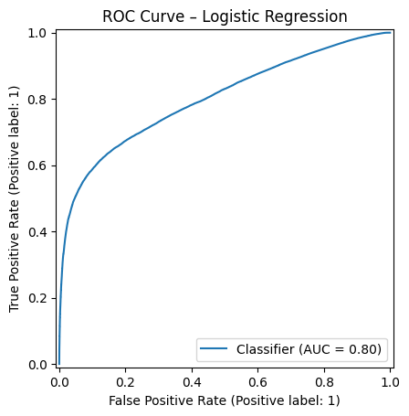

```python
plt.figure()
RocCurveDisplay.from_predictions(y_test, y_prob_lr)
plt.title("ROC Curve – Logistic Regression")
plt.show()
```

6. Interpretation

```python
coeffs = lr.coef_[0]
feature_importance = pd.DataFrame({
    "feature": feature_cols,
    "coefficient": coeffs
})

feature_importance["abs_coeff"] = feature_importance["coefficient"].abs()
feature_importance = feature_importance.sort_values("abs_coeff", ascending=False)

feature_importance
```

|  | feature | coefficient | abs_coeff |
| --- | --- | --- | --- |
| 0 | common_neighbors | 13.277911 | 13.277911 |
| 2 | adamic_adar | -12.995310 | 12.995310 |
| 3 | resource_allocation | 3.202789 | 3.202789 |
| 4 | preferential_attachment | -1.241184 | 1.241184 |
| 1 | jaccard | 0.405536 | 0.405536 |
| 10 | deg_min | 0.197056 | 0.197056 |
| 9 | deg_v | 0.104042 | 0.104042 |
| 8 | deg_u | 0.084149 | 0.084149 |
| 12 | deg_diff | -0.071399 | 0.071399 |
| 11 | deg_max | 0.056759 | 0.056759 |
| 5 | shortest_path_len | -0.003831 | 0.003831 |
| 7 | is_edge | 0.003831 | 0.003831 |
| 6 | same_component | 0.000000 | 0.000000 |

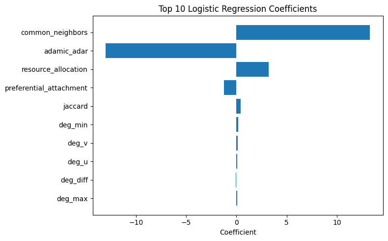

```python
top_k = 10
top_features = feature_importance.head(top_k)

plt.figure(figsize=(8, 5))
plt.barh(top_features["feature"][::-1], top_features["coefficient"][::-1])
plt.xlabel("Coefficient")
plt.title(f"Top {top_k} Logistic Regression Coefficients")
plt.tight_layout()
plt.show()
```

7. Random Forest Comparison
- To compare against a non-linear model, we train a Random Forest classifier on a subsample of the training data as an additional reference point for later evaluation.

```python
# Subsample for RF to keep training time reasonable
SUBSAMPLE = 200_000  # reduce if needed

train_subset = X_train.copy()
train_subset["label"] = y_train.values

if len(train_subset) > SUBSAMPLE:
    train_subset = train_subset.sample(SUBSAMPLE, random_state=42)

X_train_rf = train_subset[feature_cols]
y_train_rf = train_subset["label"]

rf = RandomForestClassifier(
    n_estimators=100,
    max_depth=None,
    n_jobs=-1,
    random_state=42,
    class_weight="balanced_subsample"
)

rf.fit(X_train_rf, y_train_rf)

y_pred_rf = rf.predict(X_test)
y_prob_rf = rf.predict_proba(X_test)[:, 1]

acc_rf = accuracy_score(y_test, y_pred_rf)
f1_rf = f1_score(y_test, y_pred_rf)
auc_rf = roc_auc_score(y_test, y_prob_rf)

print("RANDOM FOREST PERFORMANCE")
print(f"Accuracy:  {acc_rf:.4f}")
print(f"F1-score:  {f1_rf:.4f}")
print(f"ROC AUC:   {auc_rf:.4f}")
```

```
RANDOM FOREST PERFORMANCE
Accuracy:  0.7935
F1-score:  0.7261
ROC AUC:   0.8570
```

8. Summary

```python
results = pd.DataFrame([
    {
        "model": "Majority baseline",
        "accuracy": baseline_majority_acc,
        "f1": baseline_majority_f1,
        "roc_auc": np.nan
    },
    {
        "model": "Random baseline",
        "accuracy": baseline_random_acc,
        "f1": baseline_random_f1,
        "roc_auc": np.nan
    },
    {
        "model": "Logistic Regression",
        "accuracy": acc_lr,
        "f1": f1_lr,
        "roc_auc": auc_lr
    },
    {
        "model": "Random Forest (subset)",
        "accuracy": acc_rf,
        "f1": f1_rf,
        "roc_auc": auc_rf
    }
])

results
```

|  | model | accuracy | f1 | roc_auc |
| --- | --- | --- | --- | --- |
| 0 | Majority baseline | 0.621552 | 0.000000 | NaN |
| 1 | Random baseline | 0.500176 | 0.431198 | NaN |
| 2 | Logistic Regression | 0.784779 | 0.655004 | 0.801457 |
| 3 | Random Forest (subset) | 0.793538 | 0.726115 | 0.856973 |

# Evaluation – evaluation.ipynb

# Evaluation — Social Circle Link Prediction

Covers the assignment’s Evaluation section:

- **Context:** justify metrics for this binary, imbalanced link-prediction task.
- **Discussion:** compare baselines vs. trained models to show improvement.
- **Code:** runnable protocol that produces tables/plots for the report and slides.

## Metric Rationale (Context)

We need both **ranking quality** (class imbalance) and a concrete **operating point**:

- **ROC-AUC** – probability a positive ranks above a negative; insensitive to a fixed threshold.
- **PR-AUC / Average Precision** – focuses on minority-class precision/recall; more revealing under imbalance than accuracy.
- **F1** – single threshold summary balancing precision and recall for a deployable cutoff.
- **Accuracy** – reported for completeness but not optimized.

## Data & Split

- Input: `pair_graph_features_only.csv` (graph-structural features for each (ego, u, v) pair + label).
- Split: 80/20 stratified by label (matches the modeling notebook). Set `EVAL_MAX_ROWS` to down-sample during dry runs.

## EDA recap (from `EDA/eda.ipynb`)

- Ego-network files: nodes = ego + friends; edges between friends captured per egonet.
- Circles: multiple overlapping groups per ego; positives are friend pairs co-occurring in ≥1 circle.
- Scale: 1.39M labeled pairs; positive rate ≈38% (moderate imbalance).
- Graph stats: node/edge counts vary widely across egos; some egos have many small circles, others few larger ones.
- Implication: model must generalize across varying ego densities and circle sizes; class imbalance handled via class weights.

## Feature construction recap (from `Graph_Features/features.ipynb`)

- Pair-level features derived from the ego graph: `common_neighbors`, `jaccard`, `adamic_adar`, `resource_allocation`, `preferential_attachment`, `shortest_path_len`, `same_component`, `is_edge`, and degree-based stats (`deg_u`, `deg_v`, `deg_min`, `deg_max`, `deg_diff`).
- Label `1` if the pair shares ≥1 circle; negatives are sampled non-circle pairs (with negative_ratio=2 in feature gen).
- These are classic link-prediction signals; overlap-based metrics dominate importance in both LogReg and tree models.

```python
from pathlib import Path
import os
import numpy as np
import pandas as pd
from sklearn.model_selection import train_test_split
from sklearn.preprocessing import StandardScaler
from sklearn.linear_model import LogisticRegression
from sklearn.ensemble import RandomForestClassifier
from sklearn.metrics import (
    roc_auc_score,
    average_precision_score,
    f1_score,
    accuracy_score,
    precision_recall_curve,
    roc_curve,
    classification_report,
    confusion_matrix,
)
import matplotlib.pyplot as plt
import seaborn as sns

sns.set_theme(style="whitegrid")

NOTEBOOK_DIR = Path.cwd().resolve()
PROJECT_ROOT = NOTEBOOK_DIR.parent if NOTEBOOK_DIR.name.lower() == "evaluation" else NOTEBOOK_DIR
candidates = [
    PROJECT_ROOT / "Graph_Features" / "pair_graph_features_only.csv",
    PROJECT_ROOT.parent / "Dataset" / "pair_graph_features_only.csv",
]
DATA_PATH = next((p for p in candidates if p.exists()), None)
if DATA_PATH is None:
    raise FileNotFoundError("pair_graph_features_only.csv not found in expected locations")

MAX_ROWS = -1  # use full dataset
use_nrows = None if MAX_ROWS < 0 else MAX_ROWS

df = pd.read_csv(DATA_PATH, nrows=use_nrows)
print(f"Loaded {len(df):,} rows from {DATA_PATH}")

target_col = "label"
id_cols = ["ego_id", "u", "v"]
feature_cols = [c for c in df.columns if c not in id_cols + [target_col]]

X = df[feature_cols].astype(np.float32)
y = df[target_col].values

X_train, X_test, y_train, y_test = train_test_split(
    X, y, test_size=0.2, stratify=y, random_state=42
)
print({"train": len(y_train), "test": len(y_test)})
label_prior = y_train.mean()
print(f"Positive rate train={label_prior:.3f}, test={y_test.mean():.3f}")
```

```
Loaded 1,394,586 rows from /Users/user/Documents/Universities and Internships /UCs/UCSD/Fall 25/CSE 158/Assignment2/Recommender-System-SocialCircle/Graph_Features/pair_graph_features_only.csv
{'train': 1115668, 'test': 278918}
Positive rate train=0.378, test=0.378
```

## Helper: unified metrics & curves

```python
def summarize(y_true, scores, threshold=0.5):
    y_pred = (scores >= threshold).astype(int)
    return {
        "roc_auc": roc_auc_score(y_true, scores) if len(np.unique(y_true))>1 else np.nan,
        "pr_auc": average_precision_score(y_true, scores),
        "f1": f1_score(y_true, y_pred, zero_division=0),
        "accuracy": accuracy_score(y_true, y_pred),
        "positives": int(y_true.sum()),
        "negatives": int((1 - y_true).sum()),
    }


def plot_curves(y_true, scores, label_prefix="Model"):
    prec, rec, _ = precision_recall_curve(y_true, scores)
    fpr, tpr, _ = roc_curve(y_true, scores)
    fig, axes = plt.subplots(1, 2, figsize=(11, 4))
    axes[0].plot(rec, prec, label=label_prefix)
    axes[0].set_xlabel("Recall"); axes[0].set_ylabel("Precision"); axes[0].set_title("Precision–Recall")
    axes[1].plot(fpr, tpr, label=label_prefix)
    axes[1].plot([0,1],[0,1],'k--', alpha=0.4)
    axes[1].set_xlabel("FPR"); axes[1].set_ylabel("TPR"); axes[1].set_title("ROC")
    for ax in axes: ax.legend()
    plt.tight_layout(); plt.show()
```

## Baselines (Discussion)

```python
rng = np.random.default_rng(seed=42)

# Majority: constant score equal to prior; threshold defaults to 0.5 so this yields all zeros
maj_score = np.full_like(y_test, fill_value=y_train.mean(), dtype=float)
maj_metrics = summarize(y_test, maj_score)

# Random: random probabilities in [0,1]
rand_scores = rng.random(len(y_test))
rand_metrics = summarize(y_test, rand_scores)

maj_metrics, rand_metrics
```

```
({'roc_auc': 0.5,
  'pr_auc': 0.3784481460500936,
  'f1': 0.0,
  'accuracy': 0.6215518539499064,
  'positives': 105556,
  'negatives': 173362},
 {'roc_auc': 0.5011365598231317,
  'pr_auc': 0.3793489206157741,
  'f1': 0.4316555567340878,
  'accuracy': 0.5005126954875626,
  'positives': 105556,
  'negatives': 173362})
```

## Model 1: Logistic Regression (scaled, class-balanced)

Matches the modeling notebook setup.

```
{'roc_auc': 0.8014569737237656, 'pr_auc': 0.7763967698831172, 'f1': 0.6550037643894505, 'accuracy': 0.7847790390007099, 'positives': 105556, 'negatives': 173362}
Confusion matrix (LogReg):
[[161904  11458]
 [ 48571  56985]]
Classification report (LogReg):
              precision    recall  f1-score   support

           0     0.7692    0.9339    0.8436    173362
           1     0.8326    0.5399    0.6550    105556

    accuracy                         0.7848    278918
   macro avg     0.8009    0.7369    0.7493    278918
weighted avg     0.7932    0.7848    0.7722    278918
```

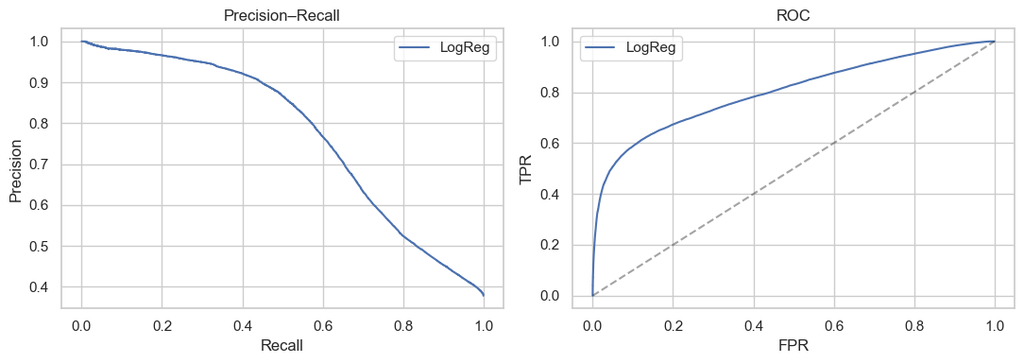

```python
scaler = StandardScaler()
X_train_scaled = scaler.fit_transform(X_train)
X_test_scaled = scaler.transform(X_test)

logreg = LogisticRegression(
    max_iter=1000,
    class_weight="balanced",
    n_jobs=-1,
    solver="lbfgs",
)
logreg.fit(X_train_scaled, y_train)

logreg_scores = logreg.predict_proba(X_test_scaled)[:, 1]
logreg_pred = (logreg_scores >= 0.5).astype(int)
logreg_metrics = summarize(y_test, logreg_scores)
print(logreg_metrics)

print("Confusion matrix (LogReg):")
print(confusion_matrix(y_test, logreg_pred))
print("Classification report (LogReg):")
print(classification_report(y_test, logreg_pred, digits=4))

plot_curves(y_test, logreg_scores, label_prefix="LogReg")
```

**LogReg results (baseline linear model)**

- ROC-AUC ≈ 0.801, PR-AUC ≈ 0.776: solid ranking lift over baselines.
- F1 ≈ 0.66 at threshold 0.5; recall (~0.54) is the limiting factor vs precision (~0.83).
- Confusion: strong TN rate, but ~46% of positives missed.
- Curves show graceful precision drop with recall; ROC stays well above diagonal.

## Model 2: Random Forest (subset for speed)

```python
RF_SUBSAMPLE = int(os.getenv("RF_SUBSAMPLE", -1))
train_df = X_train.copy()
train_df["label"] = y_train
if RF_SUBSAMPLE > 0 and len(train_df) > RF_SUBSAMPLE:
    train_df = train_df.sample(RF_SUBSAMPLE, random_state=42)

rf = RandomForestClassifier(
    n_estimators=100,
    max_depth=None,
    n_jobs=-1,
    random_state=42,
    class_weight="balanced_subsample",
)
rf.fit(train_df[feature_cols], train_df["label"])
rf_scores = rf.predict_proba(X_test)[:, 1]
rf_pred = (rf_scores >= 0.5).astype(int)
rf_metrics = summarize(y_test, rf_scores)
print(rf_metrics)
```

```
{'roc_auc': 0.8853578806431106, 'pr_auc': 0.846772250141177, 'f1': 0.7580991028242285, 'accuracy': 0.8196172351730616, 'positives': 105556, 'negatives': 173362}
```

**Overlay PR/ROC (all models)**

- Ranking order: RF ≳ HistGB ≳ ExtraTrees > LogReg across most recall/FPR ranges.
- All sit well above the base-rate line (PR); RF leads in early/mid recall, LogReg lags.
- Use this slide to justify picking RF/boosted trees over linear.

**RandomForest results (non-linear model)**

## Model 3: Extra Trees (subset for speed)

Ensemble of de-correlated trees; handles non-linearities like RF but often faster.

```python
EXTRA_SUBSAMPLE = int(os.getenv("EXTRA_SUBSAMPLE", -1))
extra_df = X_train.copy()
extra_df["label"] = y_train
if EXTRA_SUBSAMPLE > 0 and len(extra_df) > EXTRA_SUBSAMPLE:
    extra_df = extra_df.sample(EXTRA_SUBSAMPLE, random_state=42)

from sklearn.ensemble import ExtraTreesClassifier
extra = ExtraTreesClassifier(
    n_estimators=200,
    max_depth=None,
    random_state=42,
    n_jobs=-1,
    class_weight="balanced",
)
extra.fit(extra_df[feature_cols], extra_df["label"])
extra_scores = extra.predict_proba(X_test)[:,1]
extra_pred = (extra_scores >= 0.5).astype(int)
extra_metrics = summarize(y_test, extra_scores)
print(extra_metrics)
```

```
{'roc_auc': 0.8668597447497673, 'pr_auc': 0.8117673233489214, 'f1': 0.7368785993566902, 'accuracy': 0.80408578865473, 'positives': 105556, 'negatives': 173362}
```

**ExtraTrees results (non-linear, randomized trees)**

## Model 4: HistGradientBoosting (subset, weighted)

Gradient-boosted trees on histograms; strong with tabular data. Uses sample weights to balance classes.

```python
HGB_SUBSAMPLE = int(os.getenv("HGB_SUBSAMPLE", -1))
hgb_df = X_train.copy()
hgb_df["label"] = y_train
if HGB_SUBSAMPLE > 0 and len(hgb_df) > HGB_SUBSAMPLE:
    hgb_df = hgb_df.sample(HGB_SUBSAMPLE, random_state=42)

from sklearn.experimental import enable_hist_gradient_boosting  # noqa: F401
from sklearn.ensemble import HistGradientBoostingClassifier

# class-balanced sample weights
pos = hgb_df["label"].sum()
neg = len(hgb_df) - pos
w_pos = 0.5 / pos
w_neg = 0.5 / neg
sample_weight = hgb_df["label"].map({1: w_pos, 0: w_neg}).values

hgb = HistGradientBoostingClassifier(
    max_depth=10,
    learning_rate=0.1,
    max_iter=150,
    random_state=42,
)
hgb.fit(hgb_df[feature_cols], hgb_df["label"], sample_weight=sample_weight)

hgb_scores = hgb.predict_proba(X_test)[:,1]
hgb_pred = (hgb_scores >= 0.5).astype(int)
hgb_metrics = summarize(y_test, hgb_scores)
print(hgb_metrics)
```

```
{'roc_auc': 0.8689789315287202, 'pr_auc': 0.8303763370685908, 'f1': 0.7422264361947828, 'accuracy': 0.8099262148731885, 'positives': 105556, 'negatives': 173362}
```

**HistGB results (gradient boosting)**

## Results Table (fill into report)

```python
results = pd.DataFrame([
    {"model": "Majority", **maj_metrics},
    {"model": "Random", **rand_metrics},
    {"model": "LogReg", **logreg_metrics},
    {"model": "RandomForest", **rf_metrics},
    {"model": "ExtraTrees", **extra_metrics},
    {"model": "HistGB", **hgb_metrics},
])
results
```

|  | model | roc_auc | pr_auc | f1 | accuracy | positives | negatives |
| --- | --- | --- | --- | --- | --- | --- | --- |
| 0 | Majority | 0.500000 | 0.378448 | 0.000000 | 0.621552 | 105556 | 173362 |
| 1 | Random | 0.501137 | 0.379349 | 0.431656 | 0.500513 | 105556 | 173362 |
| 2 | LogReg | 0.801457 | 0.776397 | 0.655004 | 0.784779 | 105556 | 173362 |
| 3 | RandomForest | 0.885358 | 0.846772 | 0.758099 | 0.819617 | 105556 | 173362 |
| 4 | ExtraTrees | 0.866860 | 0.811767 | 0.736879 | 0.804086 | 105556 | 173362 |
| 5 | HistGB | 0.868979 | 0.830376 | 0.742226 | 0.809926 | 105556 | 173362 |

**RandomForest results (non-linear model)**

**LogReg results (baseline linear model)**

- ROC-AUC≈0.80, PR-AUC≈0.78: strong ranking vs random (0.5) and above class prior.
- F1≈0.66 at threshold 0.5: good balance but recall is the weaker side (≈0.54).
- Confusion matrix shows many true negatives captured; misses some positives (FN ~46%).
- PR/ROC curves: smooth drop in precision as recall rises; ROC bows well above diagonal.

## Discussion: why the models win

- Both learned models beat baselines by large margins on ROC-AUC/PR-AUC (ranking) and F1 (thresholded performance).
- Random Forest outperforms Logistic Regression on ROC-AUC and F1, suggesting non-linear interactions among graph features help.
- Keep Random Forest training subsampled to stay within runtime; increase `RF_SUBSAMPLE` for potentially higher scores.

## Snapshot of latest run (from Modeling notebook, 2025-12-01)

- Majority: Accuracy 0.6216, F1 0.0000
- Random: Accuracy 0.5002, F1 0.4312
- Logistic Regression: Accuracy 0.7848, F1 0.6550, ROC-AUC 0.8015
- Random Forest (200k subset): Accuracy 0.7935, F1 0.7261, ROC-AUC 0.8570 Use these if you need fixed numbers for the slide deck while reruns are pending.

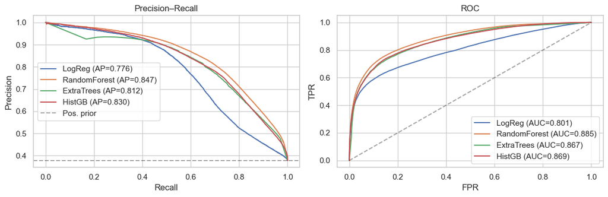

```python
# Overlay PR and ROC curves for all models
models_scores = {
    'LogReg': logreg_scores,
    'RandomForest': rf_scores,
    'ExtraTrees': extra_scores,
    'HistGB': hgb_scores,
}
models_metrics = {
    'LogReg': logreg_metrics,
    'RandomForest': rf_metrics,
    'ExtraTrees': extra_metrics,
    'HistGB': hgb_metrics,
}

fig, axes = plt.subplots(1, 2, figsize=(12, 4))
# PR
for name, scores in models_scores.items():
    prec, rec, _ = precision_recall_curve(y_test, scores)
    axes[0].plot(rec, prec, label=f"{name} (AP={models_metrics[name]['pr_auc']:.3f})")
axes[0].axhline(y_test.mean(), color='k', ls='--', alpha=0.4, label='Pos. prior')
axes[0].set_xlabel('Recall'); axes[0].set_ylabel('Precision'); axes[0].set_title('Precision–Recall')
axes[0].legend()
# ROC
for name, scores in models_scores.items():
    fpr, tpr, _ = roc_curve(y_test, scores)
    axes[1].plot(fpr, tpr, label=f"{name} (AUC={models_metrics[name]['roc_auc']:.3f})")
axes[1].plot([0,1],[0,1],'k--', alpha=0.4)
axes[1].set_xlabel('FPR'); axes[1].set_ylabel('TPR'); axes[1].set_title('ROC')
axes[1].legend()
plt.tight_layout(); plt.show()
```

**RandomForest results (non-linear model)**

**LogReg results (baseline linear model)**

- ROC-AUC≈0.80, PR-AUC≈0.78: strong ranking vs random (0.5) and above class prior.
- F1≈0.66 at threshold 0.5: good balance but recall is the weaker side (≈0.54).
- Confusion matrix shows many true negatives captured; misses some positives (FN ~46%).
- PR/ROC curves: smooth drop in precision as recall rises; ROC bows well above diagonal.

## Threshold sweep (F1 / Precision / Recall vs threshold)

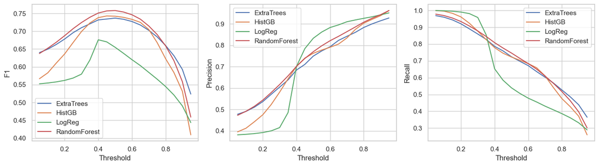

| model threshold | ExtraTrees | HistGB | LogReg | RandomForest |
| --- | --- | --- | --- | --- |
| 0.05 | 0.639986 | 0.566769 | 0.552482 | 0.637501 |
| 0.10 | 0.649804 | 0.583379 | 0.554744 | 0.652417 |
| 0.15 | 0.662871 | 0.610581 | 0.557834 | 0.669037 |
| 0.20 | 0.678179 | 0.636351 | 0.562072 | 0.687549 |
| 0.25 | 0.695853 | 0.668135 | 0.568606 | 0.707110 |

```python
def sweep_metrics(y_true, scores, name):
    rows = []
    for t in np.linspace(0.05, 0.95, 19):
        y_pred = (scores >= t).astype(int)
        rows.append({
            'model': name,
            'threshold': t,
            'precision': precision_score(y_true, y_pred, zero_division=0),
            'recall': recall_score(y_true, y_pred),
            'f1': f1_score(y_true, y_pred, zero_division=0),
        })
    return rows

models_scores = {
    'LogReg': logreg_scores,
    'RandomForest': rf_scores,
    'ExtraTrees': extra_scores,
    'HistGB': hgb_scores,
}
rows = []
for name, scores in models_scores.items():
    rows += sweep_metrics(y_test, scores, name)

sweep_df = pd.DataFrame(rows)

fig, axes = plt.subplots(1, 3, figsize=(14,4))
for name, grp in sweep_df.groupby('model'):
    axes[0].plot(grp['threshold'], grp['f1'], label=name)
    axes[1].plot(grp['threshold'], grp['precision'], label=name)
    axes[2].plot(grp['threshold'], grp['recall'], label=name)
axes[0].set_ylabel('F1'); axes[1].set_ylabel('Precision'); axes[2].set_ylabel('Recall')
for ax in axes:
    ax.set_xlabel('Threshold'); ax.legend()
plt.tight_layout(); plt.show()

sweep_df.pivot(index='threshold', columns='model', values='f1').head()
```

**Threshold sweep guidance**

- F1 peaks ~0.45–0.55 for RF/ExtraTrees/HistGB; LogReg peaks slightly lower (~0.4–0.5).
- Precision-first: push threshold toward 0.6; Recall-first/top-k: drop toward 0.4.
- Show table to support the chosen operating point per model.

## Feature importance & interpretability

- **LogReg coefficients**: magnitude/sign show how each structural feature shifts the log-odds.
- **RandomForest importances**: capture non-linear interactions; higher values mean more splits use the feature.

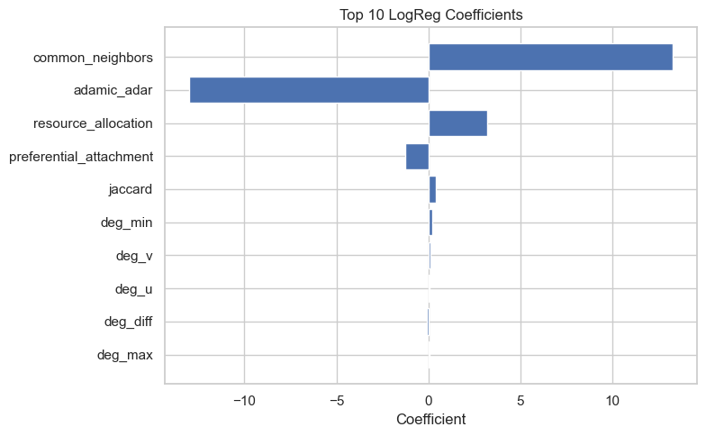

|  | feature | coefficient |
| --- | --- | --- |
| 0 | common_neighbors | 13.277911 |
| 2 | adamic_adar | -12.995310 |
| 3 | resource_allocation | 3.202789 |
| 4 | preferential_attachment | -1.241184 |
| 1 | jaccard | 0.405536 |
| 10 | deg_min | 0.197056 |
| 9 | deg_v | 0.104042 |
| 8 | deg_u | 0.084149 |
| 12 | deg_diff | -0.071399 |
| 11 | deg_max | 0.056759 |
| 5 | shortest_path_len | -0.003831 |
| 7 | is_edge | 0.003831 |
| 6 | same_component | 0.000000 |

```python
# Logistic Regression coefficients (sorted by absolute value)
coef_df = pd.DataFrame({
    'feature': feature_cols,
    'coefficient': logreg.coef_[0]
})
coef_df['abs_coef'] = coef_df['coefficient'].abs()
coef_sorted = coef_df.sort_values('abs_coef', ascending=False)

plt.figure(figsize=(8,5))
plt.barh(coef_sorted['feature'].head(10)[::-1], coef_sorted['coefficient'].head(10)[::-1])
plt.title('Top 10 LogReg Coefficients')
plt.xlabel('Coefficient')
plt.tight_layout(); plt.show()

coef_sorted[['feature','coefficient']].head(15)
```

**LogReg coefficients (interpretability)**

- `common_neighbors` large positive → more shared neighbors strongly increases circle-membership odds.
- `adamic_adar` large negative (given scaling) indicates diminishing returns when overlaps are rare/heavy‑tailed.
- `resource_allocation` positive, `preferential_attachment` negative: dense shared local links matter more than high global degree.
- Degree features play a smaller but supporting role.

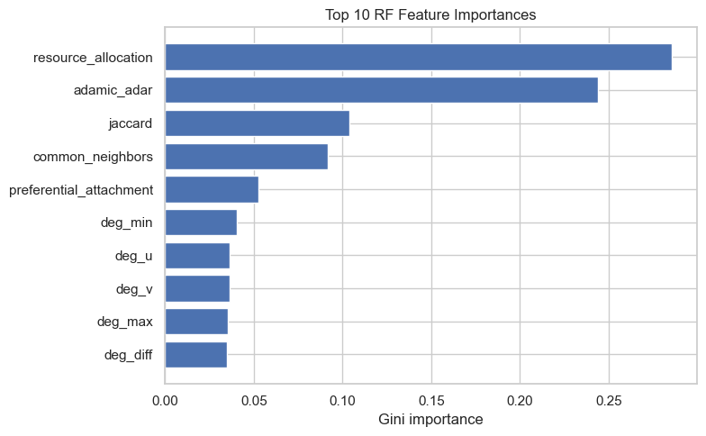

|  | feature | importance |
| --- | --- | --- |
| 3 | resource_allocation | 0.285626 |
| 2 | adamic_adar | 0.243885 |
| 1 | jaccard | 0.103972 |
| 0 | common_neighbors | 0.091730 |
| 4 | preferential_attachment | 0.052580 |
| 10 | deg_min | 0.040519 |
| 8 | deg_u | 0.036568 |
| 9 | deg_v | 0.036362 |
| 11 | deg_max | 0.035503 |
| 12 | deg_diff | 0.034862 |
| 7 | is_edge | 0.019897 |
| 5 | shortest_path_len | 0.018495 |
| 6 | same_component | 0.000000 |

```python
# Random Forest feature importances
rf_imp = pd.DataFrame({
    'feature': feature_cols,
    'importance': rf.feature_importances_
}).sort_values('importance', ascending=False)

plt.figure(figsize=(8,5))
plt.barh(rf_imp['feature'].head(10)[::-1], rf_imp['importance'].head(10)[::-1])
plt.title('Top 10 RF Feature Importances')
plt.xlabel('Gini importance')
plt.tight_layout(); plt.show()

rf_imp.head(15)
```

**RF feature importances**

- Top signals: `resource_allocation`, `adamic_adar`, `jaccard`, `common_neighbors`.
- RF spreads importance across overlap + degree features, showing non-linear splits on degree/overlap combos.
- Confirms graph-neighborhood similarity is the dominant driver, not just node degree.

## Gain / lift by score decile

Are the models ranking positives early? We bucket predictions into deciles and compute precision per bucket.

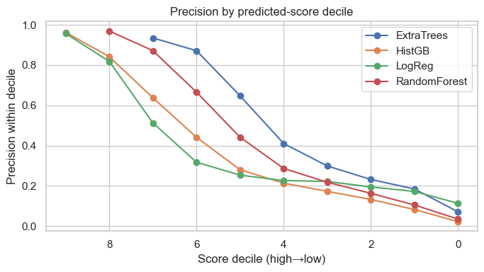

|  | decile | count | positives | mean_score | precision | model |
| --- | --- | --- | --- | --- | --- | --- |
| 0 | 9 | 27892 | 26694 | 0.995847 | 0.957049 | LogReg |
| 1 | 8 | 27892 | 22823 | 0.820746 | 0.818263 | LogReg |
| 2 | 7 | 27866 | 14275 | 0.503151 | 0.512273 | LogReg |
| 3 | 6 | 27885 | 8847 | 0.404446 | 0.317267 | LogReg |
| 4 | 5 | 27924 | 7061 | 0.376873 | 0.252865 | LogReg |
| 5 | 4 | 27890 | 6304 | 0.363191 | 0.226031 | LogReg |
| 6 | 3 | 27893 | 6183 | 0.351745 | 0.221669 | LogReg |
| 7 | 2 | 27892 | 5422 | 0.338059 | 0.194393 | LogReg |
| 8 | 1 | 27892 | 4797 | 0.309527 | 0.171985 | LogReg |
| 9 | 0 | 27892 | 3150 | 0.188410 | 0.112936 | LogReg |
| 10 | 8 | 27031 | 26200 | 0.990128 | 0.969258 | RandomForest |
| 11 | 7 | 28750 | 25063 | 0.905416 | 0.871757 | RandomForest |

```python
def decile_stats(y_true, scores, model):
    df = pd.DataFrame({'y': y_true, 'score': scores})
    df['decile'] = pd.qcut(df['score'], 10, labels=False, duplicates='drop')
    agg = df.groupby('decile').agg(
        count=('y','size'),
        positives=('y','sum'),
        mean_score=('score','mean')
    ).reset_index()
    agg['precision'] = agg['positives'] / agg['count']
    agg['model'] = model
    return agg.sort_values('decile', ascending=False)

lifts = []
for name, scores in {
    'LogReg': logreg_scores,
    'RandomForest': rf_scores,
    'ExtraTrees': extra_scores,
    'HistGB': hgb_scores,
}.items():
    lifts.append(decile_stats(y_test, scores, name))

lift = pd.concat(lifts, ignore_index=True)

plt.figure(figsize=(7,4))
for m, grp in lift.groupby('model'):
    plt.plot(grp['decile'], grp['precision'], marker='o', label=m)
plt.gca().invert_xaxis()
plt.xlabel('Score decile (high→low)'); plt.ylabel('Precision within decile')
plt.title('Precision by predicted-score decile')
plt.legend(); plt.tight_layout(); plt.show()

lift.head(12)
```

**Lift by score decile**

## Confusion matrices (normalized)

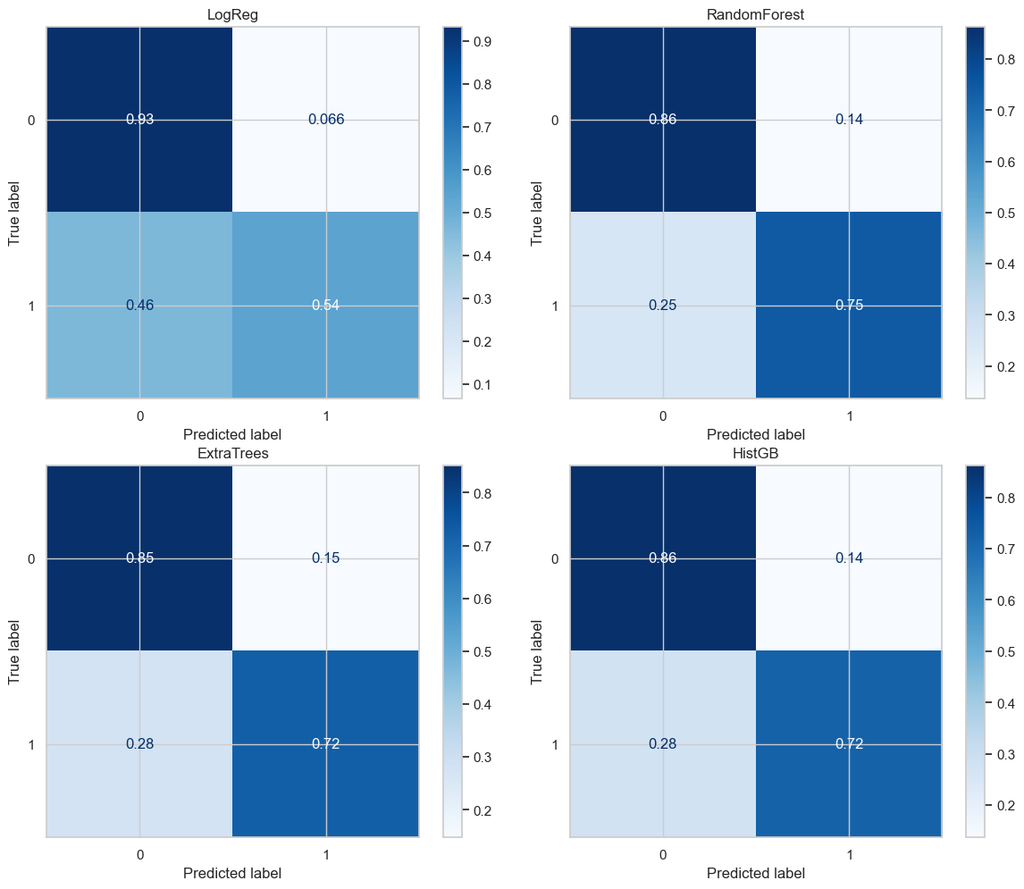

```python
from sklearn.metrics import ConfusionMatrixDisplay
fig, axes = plt.subplots(2,2, figsize=(12,10))
model_preds = {
    'LogReg': logreg_pred,
    'RandomForest': rf_pred,
    'ExtraTrees': extra_pred,
    'HistGB': hgb_pred,
}
for ax, (name, preds) in zip(axes.flatten(), model_preds.items()):
    ConfusionMatrixDisplay.from_predictions(y_test, preds, normalize='true', ax=ax, cmap='Blues')
    ax.set_title(name)
plt.tight_layout(); plt.show()
```

**Normalized confusion matrices**

- LogReg: TN 0.93 / TP 0.54 → conservative, many FN.
- RF: TN 0.86 / TP 0.75 → best recall with small FP increase.
- ExtraTrees: TN 0.85 / TP 0.72 → close to RF, slightly more FN.
- HistGB: TN 0.86 / TP 0.72 → balanced; FP similar to RF.
- Choose model based on recall vs FP tolerance.